# Aprendizaje supervisado: modelos lineales

Workbooks de la asignatura Aprendizaje Supervisado I

Author

Javier Álvarez Liébana

- **Diapositivas**: las diapositivas usadas en el aula a lo largo del curso, estructuradas por clases, estarán disponibles y actualizadas en **https://javieralvarezliebana.es/docencia/supervisado-datascience/diapos**
- **Datos**: [**acceso a Drive**](https://drive.google.com/drive/folders/1sim9xjM2qRcWrsMHrv_qRlkwDbGKOWN9?usp=sharing) y [**Github**](https://github.com/dadosdelaplace/docencia/tree/main/supervisado-datascience/workbook/datos)

## 1 Clase 1

### 1.1 🐣 Caso práctico I: anscombe

En el paquete `{datasets}` se encuentra el dataset conocido como **cuarteto de Anscombe**, un dataset que cuenta con 4 conjuntos de datos, cada uno de ellos cuenta con 11 observaciones de una variable x y otra y.

```r
library(tidyverse)
anscombe_tb <- as_tibble(datasets::anscombe)
anscombe_tb
```

```
# A tibble: 11 × 8
      x1    x2    x3    x4    y1    y2    y3    y4
   <dbl> <dbl> <dbl> <dbl> <dbl> <dbl> <dbl> <dbl>
 1    10    10    10     8  8.04  9.14  7.46  6.58
 2     8     8     8     8  6.95  8.14  6.77  5.76
 3    13    13    13     8  7.58  8.74 12.7   7.71
 4     9     9     9     8  8.81  8.77  7.11  8.84
 5    11    11    11     8  8.33  9.26  7.81  8.47
 6    14    14    14     8  9.96  8.1   8.84  7.04
 7     6     6     6     8  7.24  6.13  6.08  5.25
 8     4     4     4    19  4.26  3.1   5.39 12.5
 9    12    12    12     8 10.8   9.13  8.15  5.56
10     7     7     7     8  4.82  7.26  6.42  7.91
11     5     5     5     8  5.68  4.74  5.73  6.89
```

#### 1.1.1 Pregunta 1

> Convierte a tidy data. Debes acabar con un dataset de 44 filas (11 valores para cada dataset) y 3 columnas (dataset, x e y)

```r
anscombe_x <-
  anscombe_tb |>
  pivot_longer(cols = x1:x4, names_to = "dataset", values_to = "x",
               names_prefix = "x") |>
  select(-contains("y"))

anscombe_y <-
  anscombe_tb |>
  pivot_longer(cols = y1:y4, names_to = "dataset", values_to = "y",
               names_prefix = "y") |>
  select(-contains("x"))

anscombe_tidy <-
  anscombe_x |>
  mutate("y" = anscombe_y$y)
anscombe_tidy
```

```
# A tibble: 44 × 3
   dataset     x     y
   <chr>   <dbl> <dbl>
 1 1          10  8.04
 2 2          10  9.14
 3 3          10  7.46
 4 4           8  6.58
 5 1           8  6.95
 6 2           8  8.14
 7 3           8  6.77
 8 4           8  5.76
 9 1          13  7.58
10 2          13  8.74
# ℹ 34 more rows
```

#### 1.1.2 Pregunta 2

> Calcula la media, varianza, desv. típica de x e y en cada dataset por separado

```r
anscombe_tidy |>
  summarise(mean_x = mean(x), mean_y = mean(y),
            var_x = var(x), var_y = var(y),
            sd_x = sd(x), sd_y = sd(y),
            .by = dataset)
```

[output not shown]

#### 1.1.3 Pregunta 3

> Calcula la covarianza y correlación entre x e y en cada dataset

```r
anscombe_tidy |>
  summarise(cov = cov(x, y), cor = cor(x, y),
            .by = dataset)
```

[output not shown]

#### 1.1.4 Pregunta 4

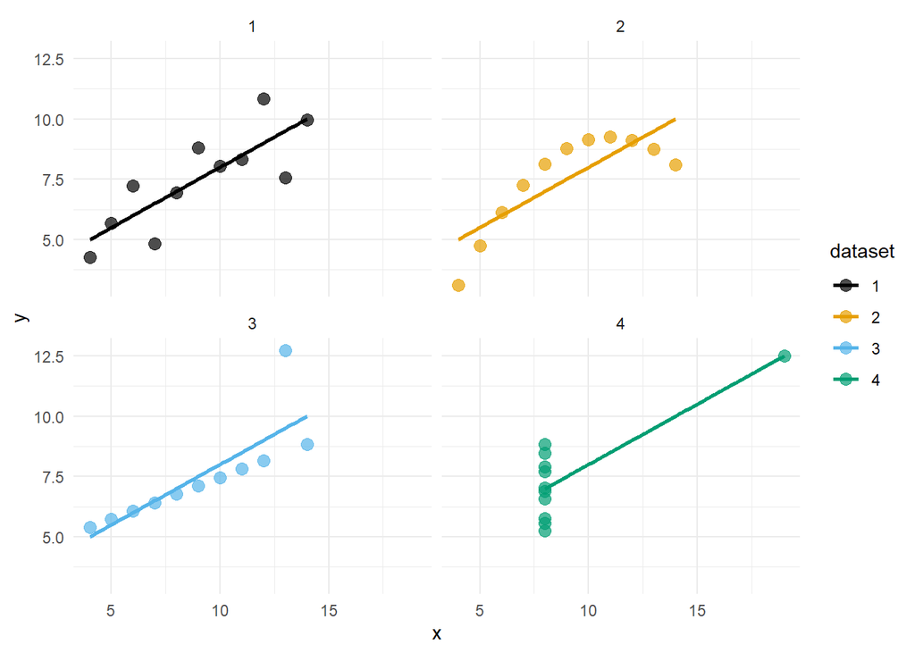

```r
ggplot(anscombe_tidy, aes(x = x, y = y, color = dataset)) +
  geom_point(size = 3, alpha = 0.7) +
  geom_smooth(method = "lm", se = FALSE) +
  ggthemes::scale_color_colorblind() +
  facet_wrap(~dataset) +
  theme_minimal()
```

Por suerte o por desgracia **no todo son matemáticas**: antes de pensar que modelo es mejor para nuestros datos, es importantísimo realizar un **análisis exploratorio** de los mismos (incluyendo visualización)

#### 1.1.5 Pregunta 5

> Podemos visualizarlo de manera aún más extrema con el dataset `datasaurus_dozen` del paquete `{datasauRus}` (ver más en https://www.research.autodesk.com/publications/same-stats-different-graphs/). Calcula de nuevo, para cada dataset, media, varianza, desv. típica, covarianza y correlación

```r
library(datasauRus)
datasaurus_dozen |>
  summarise(mean_x = mean(x), mean_y = mean(y),
            var_x = var(x), var_y = var(y),
            sd_x = sd(x), sd_y = sd(y),
            cov = cov(x, y), cor = cor(x, y), .by = dataset)
```

[output not shown]

#### 1.1.6 Pregunta 6

> Elimina el dataset `"wide_lines"` y visualiza los 12 datasets restantes mediante un diagrama de dispersión (con su ajuste de regresión)

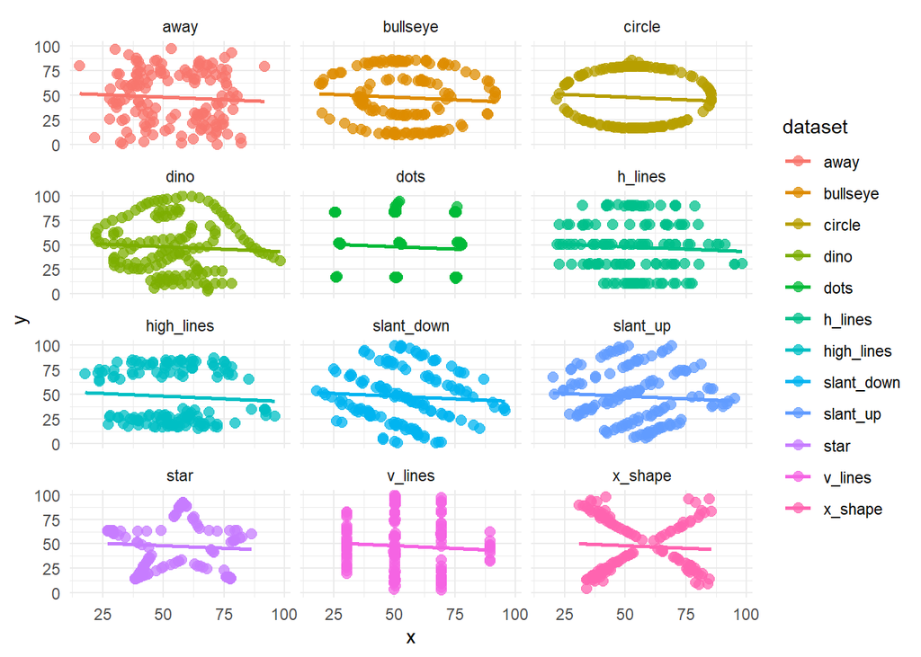

```r
library(datasauRus)
ggplot(datasaurus_dozen |> filter(dataset != "wide_lines"),
       aes(x = x, y = y, color = dataset)) +
  geom_point(size = 2.5, alpha = 0.75) +
  geom_smooth(method = "lm", se = FALSE)  +
  facet_wrap(~dataset, ncol = 3) +
  theme_minimal()
```

## 2 Clase 2

### 2.1 💻 Ejercicios resueltos: tablas de frecuencia

#### 2.1.1 Ejercicio 1

Para repasar lo aprendido vamos a poner todo en práctica con el dataset `SatisfaccionPacientes.csv`.

```r
library(readr)
datos <-
  read_csv(file = "./datos/SatisfaccionPacientes.csv") |>
  janitor::clean_names()
```

📝 Aplica el código que sea necesario para responder a estas preguntas. ¿Cuál es el tamaño muestral? ¿Cuántas variables tenemos? ¿Cuántas modalidades tenemos en la variable `estado_civil` (y cuantas observaciones en cada una)?

```r
# Tamaño muestral / número de observaciones
n <- nrow(datos)

# Número de variables
p <- ncol(datos)

# ¿Qué modalidades tenemos?
datos |>  count(estado_civil)
```

```
# A tibble: 4 × 2
  estado_civil     n
  <chr>        <int>
1 Casado          26
2 Divorciado      19
3 Soltero         42
4 Viudo           13
```

#### 2.1.2 Ejercicio 2

📝 Determina el tipo de variable (cuantitativa vs. cualitativa).

```r
# Variables cuantitativas: tiempo, grado satisfacción, número de visitas
# Variables cualitativas: género, estado civil, estado salud
glimpse(datos)
```

```
Rows: 100
Columns: 8
$ id                 <dbl> 1, 2, 3, 4, 5, 6, 7, 8, 9, 10, 11, 12, 13, 14, 15, …
$ edad               <dbl> 60, 44, 43, 32, 66, 43, 54, 55, 56, 34, 56, 57, 38,…
$ genero             <chr> "Masculino", "Femenino", "Masculino", "Masculino", …
$ estado_civil       <chr> "Casado", "Soltero", "Soltero", "Soltero", "Divorci…
$ tiempo_espera      <dbl> 28, 22, 8, 21, 7, 20, 18, 29, 17, 34, 20, 29, 2, 31…
$ grado_satisfaccion <dbl> 8, 8, 9, 8, 10, 8, 6, 6, 9, 8, 9, 8, 8, 8, 9, 8, 10…
$ numero_visitas     <dbl> 10, 1, 2, 8, 3, 10, 7, 1, 2, 3, 3, 6, 10, 5, 4, 2, …
$ estado_salud       <chr> "Regular", "Bueno", "Bueno", "Bueno", "Malo", "Buen…
```

#### 2.1.3 Ejercicio 3

📝 Obten tablas de frecuencias (absoluta y relativa) en el caso de las cualitativas NOMINALES. Con ella intenta responder a las preguntas: a) ¿cuántas mujeres hay? b) ¿qué % de individuos están casados?

```r
# no podemos calcular acumulados ya que genero es nominal
datos |>  count(genero) |>
  rename(frecuencia_abs = n) |>
  mutate(frecuencia_rel = frecuencia_abs/sum(frecuencia_abs))
```

```
# A tibble: 2 × 3
  genero    frecuencia_abs frecuencia_rel
  <chr>              <int>          <dbl>
1 Femenino              53           0.53
2 Masculino             47           0.47
```

```r
# Hay 53 mujeres

datos |> count(estado_civil) |>
  rename(frecuencia_abs = n) |>
  mutate(frecuencia_rel = frecuencia_abs/sum(frecuencia_abs))
```

```
# A tibble: 4 × 3
  estado_civil frecuencia_abs frecuencia_rel
  <chr>                 <int>          <dbl>
1 Casado                   26           0.26
2 Divorciado               19           0.19
3 Soltero                  42           0.42
4 Viudo                    13           0.13
```

```r
# Hay 26% personas casadas
```

#### 2.1.4 Ejercicio 4

📝 Convierte de manera adecuada la variable `genero` y `estado_civil` a cualitativa nominal

```r
datos <-
  datos |>
  mutate(estado_civil = factor(estado_civil),
         genero = factor(genero))
datos
```

```
# A tibble: 100 × 8
      id  edad genero    estado_civil tiempo_espera grado_satisfaccion
   <dbl> <dbl> <fct>     <fct>                <dbl>              <dbl>
 1     1    60 Masculino Casado                  28                  8
 2     2    44 Femenino  Soltero                 22                  8
 3     3    43 Masculino Soltero                  8                  9
 4     4    32 Masculino Soltero                 21                  8
 5     5    66 Masculino Divorciado               7                 10
 6     6    43 Masculino Divorciado              20                  8
 7     7    54 Masculino Casado                  18                  6
 8     8    55 Masculino Soltero                 29                  6
 9     9    56 Masculino Viudo                   17                  9
10    10    34 Femenino  Casado                  34                  8
# ℹ 90 more rows
# ℹ 2 more variables: numero_visitas <dbl>, estado_salud <chr>
```

#### 2.1.5 Ejercicio 5

📝 Calcula la media, mediana, rango intercuartílico y desviación típica de edad y tiempo de espera.

```r
resumen <-
  datos |>
  summarise(media_edad = mean(edad), sd_edad = sd(edad), mediana_edad = median(edad),
           IQR_edad = quantile(edad, probs = 0.75) - quantile(edad, probs = 0.25),
           # tiempo espera
           media_tiempo_espera = mean(tiempo_espera), sd_tiempo_espera = sd(tiempo_espera),
           mediana_tiempo_espera = median(tiempo_espera),
           IQR_tiempo_espera = quantile(tiempo_espera, probs = 0.75) - quantile(tiempo_espera, probs = 0.25))
resumen
```

```
# A tibble: 1 × 8
  media_edad sd_edad mediana_edad IQR_edad media_tiempo_espera sd_tiempo_espera
       <dbl>   <dbl>        <dbl>    <dbl>               <dbl>            <dbl>
1       52.5    14.5           54     19.2                22.6             9.89
# ℹ 2 more variables: mediana_tiempo_espera <dbl>, IQR_tiempo_espera <dbl>
```

#### 2.1.6 Ejercicio 6

📝 Repite el anterior ejercicio pero obteniendo las métricas desagregadas por sexo.

```r
resumen <-
  datos |>
  summarise(media_edad = mean(edad), sd_edad = sd(edad), mediana_edad = median(edad),
           IQR_edad = quantile(edad, probs = 0.75) - quantile(edad, probs = 0.25),
           # tiempo espera
           media_tiempo_espera = mean(tiempo_espera), sd_tiempo_espera = sd(tiempo_espera),
           mediana_tiempo_espera = median(tiempo_espera),
           IQR_tiempo_espera = quantile(tiempo_espera, probs = 0.75) - quantile(tiempo_espera, probs = 0.25),
          .by = genero)
resumen
```

```
# A tibble: 2 × 9
  genero    media_edad sd_edad mediana_edad IQR_edad media_tiempo_espera
  <fct>          <dbl>   <dbl>        <dbl>    <dbl>               <dbl>
1 Masculino       52.9    14.9           54     18.5                17.0
2 Femenino        52.1    14.3           52     20                  27.5
# ℹ 3 more variables: sd_tiempo_espera <dbl>, mediana_tiempo_espera <dbl>,
#   IQR_tiempo_espera <dbl>
```

#### 2.1.7 Ejercicio 7

📝 Realiza un gráfico de violín para la variable `tiempo_espera` para cada género

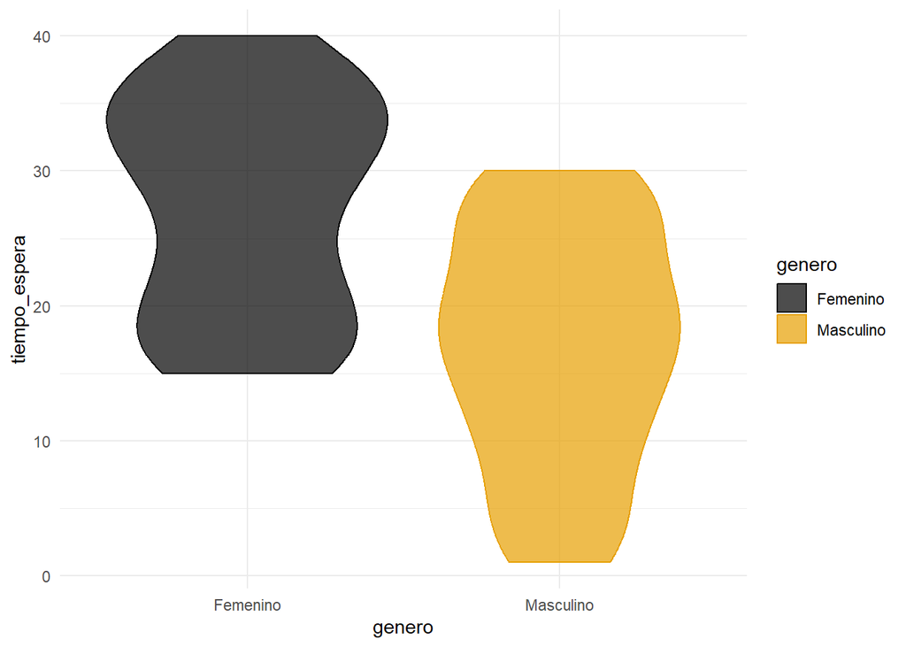

```r
ggplot(datos) +
  geom_violin(aes(x = genero, y = tiempo_espera, fill = genero, color = genero),
              alpha = 0.7) +
  ggthemes::scale_color_colorblind() +
  ggthemes::scale_fill_colorblind() +
  theme_minimal()
```

### 2.2 💻 Ejercicios resueltos: cuali vs cuali

#### 2.2.1 Ejercicio 1

📝 Carga el fichero `placebo_medicamento_completo.csv` donde tenemos guardado los niveles de colesterol antes y después de un tratamiento: a 76 personas se les dio un medicamento para bajarlo y a 24 personas placebo.

```r
datos <- read_csv(file = "./datos/placebo_medicamento_completo.csv")
datos
```

```
# A tibble: 100 × 4
      id tratamiento colesterol_pre colesterol_post
   <dbl> <chr>                <dbl>           <dbl>
 1     1 medicamento           150.            144.
 2     2 medicamento           138.            136.
 3     3 medicamento           153.            150.
 4     4 medicamento           131.            123.
 5     5 medicamento           117.            113.
 6     6 medicamento           141.            139.
 7     7 medicamento           141.            143.
 8     8 medicamento           133.            127.
 9     9 medicamento           154.            149.
10    10 medicamento           153.            146.
# ℹ 90 more rows
```

#### 2.2.2 Ejercicio 2

📝 Añade una nueva variable dicotómica a los datos que nos guarde `mejora` si el paciente mejoró tras el tratamiento y `no mejora` en caso negativo

```r
datos <-
  datos |>
  mutate("mejora" = if_else(colesterol_post <= colesterol_pre, "mejora",
                            "no mejora"))
datos
```

```
# A tibble: 100 × 5
      id tratamiento colesterol_pre colesterol_post mejora
   <dbl> <chr>                <dbl>           <dbl> <chr>
 1     1 medicamento           150.            144. mejora
 2     2 medicamento           138.            136. mejora
 3     3 medicamento           153.            150. mejora
 4     4 medicamento           131.            123. mejora
 5     5 medicamento           117.            113. mejora
 6     6 medicamento           141.            139. mejora
 7     7 medicamento           141.            143. no mejora
 8     8 medicamento           133.            127. mejora
 9     9 medicamento           154.            149. mejora
10    10 medicamento           153.            146. mejora
# ℹ 90 more rows
```

#### 2.2.3 Ejercicio 3

📝 Visualiza ambas variables (`mejora` y `tratamiento`) a la vez con un diagrama de barras de manera que podamos observar indicios de una posible independencia o dependencia entre ambas. Hazlo antes a papel y boli si lo necesitas

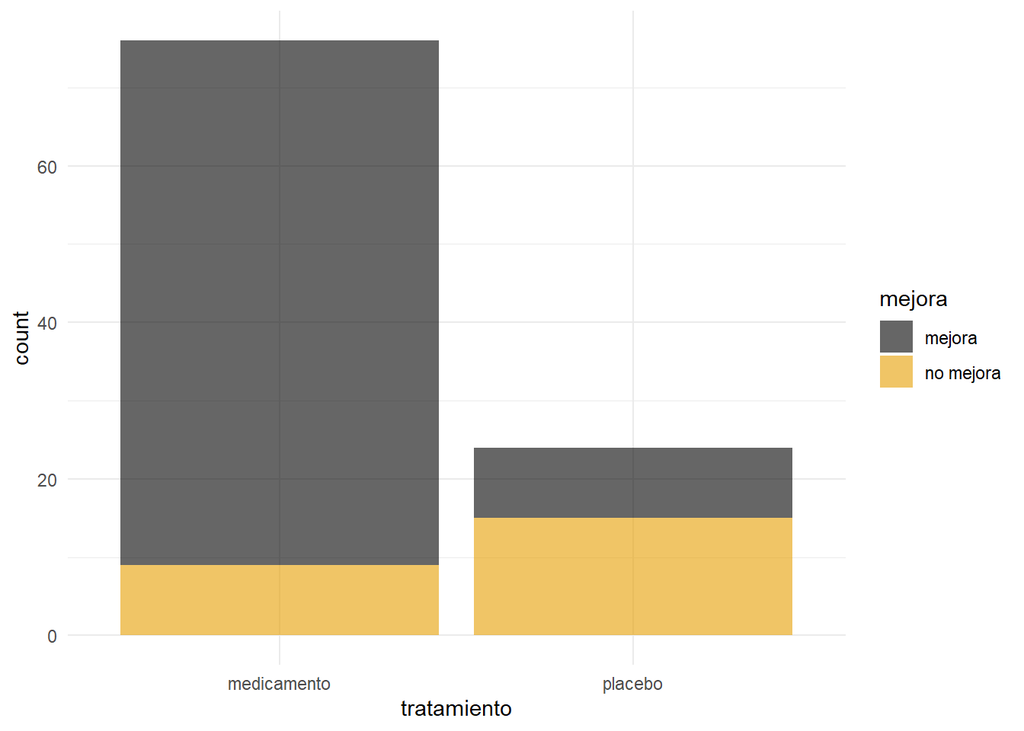

```r
# así pintaríamos en cada barra de tratamiento los mejora o no mejora
ggplot(datos) +
  geom_bar(aes(x = tratamiento, fill = mejora), alpha = 0.6) +
  ggthemes::scale_fill_colorblind() +
  theme_minimal()
```

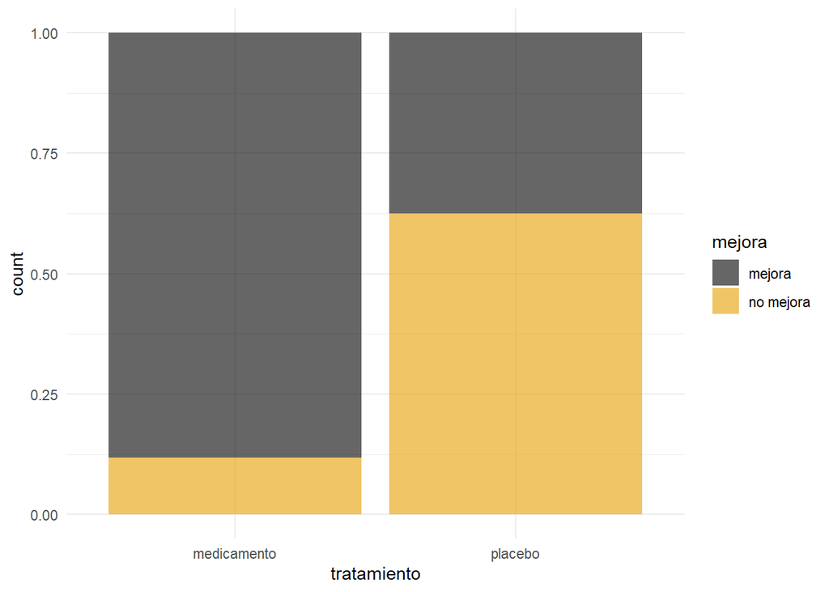

```r
# pero dado que tienes más tratados que del grupo control
# no permite comparar bien así que igualamos las barras
# para que cada barra sea el 100% de su categoría
ggplot(datos) +
  geom_bar(aes(x = tratamiento, fill = mejora), alpha = 0.6,
           position = "fill") +
  ggthemes::scale_fill_colorblind() +
  theme_minimal()
```

```r
# Parece evidente visualmente que hay una diferencia entre mejora y no mejora
# en cada barra
```

#### 2.2.4 Ejercicio 4

📝 Calcula la tabla de frecuencias absoluta y relativa que consideres necesarias para responder a las siguientes preguntas:

1. ¿Cuántas personas de las tratadas con medicamento no mejoraron?
2. ¿Qué de personas del total del estudio acabaron mejorando habiendo tomando placebo?
3. ¿Qué % de personas tomó medicamentos entre los que no mejoraron?
4. ¿Qué % de personas de los que tomaron medicamento mejoraron?

```r
table(datos$tratamiento, datos$mejora)
```

```
              mejora no mejora
  medicamento     67         9
  placebo          9        15
```

```r
prop.table(table(datos$tratamiento, datos$mejora))
```

```
              mejora no mejora
  medicamento   0.67      0.09
  placebo       0.09      0.15
```

```r
prop.table(table(datos$tratamiento, datos$mejora), margin = 1)
```

```
                 mejora no mejora
  medicamento 0.8815789 0.1184211
  placebo     0.3750000 0.6250000
```

```r
prop.table(table(datos$tratamiento, datos$mejora), margin = 2)
```

```
                 mejora no mejora
  medicamento 0.8815789 0.3750000
  placebo     0.1184211 0.6250000
```

```r
# 9 personas de las tratadas con medicamento no mejoraron
# 9% del total de personas mejoraron y tomaron placebo
# 37% de los que no mejoraron habían tomado la medicación
# 88.1% de los que tomaron medicamento mejoraron
```

#### 2.2.5 Ejercicio 5

📝 Para confirmar y cuantificar las evidencias que ya tenemos, vamos a realizar un contraste de hipótesis. Realiza la prueba de chi-cuadrado e interpreta el resultado con $\alpha = 0.05$.

```r
chisq.test(datos$tratamiento, datos$mejora)
```

```
    Pearson's Chi-squared test with Yates' continuity correction

data:  datos$tratamiento and datos$mejora
X-squared = 22.96, df = 1, p-value = 1.654e-06
```

```r
# Dado que p-value = 1.654e-06 << alpha --> debemos rechazar la hipótesis nula -->
# hay evidencias suficientes para afirmar que hay relación de dependencia
```

#### 2.2.6 Ejercicio 6

> Realiza la prueba de chi-cuadrado y Fisher e incluye los p-valores en una tabla resumen haciendo uso de tidyverse. Exporta a un `.csv` dicha tabla resumen

```r
resumen_pvalores <-
  datos |>
  summarise("sig_chisq" = chisq.test(datos$tratamiento, datos$mejora)$p.value,
            "sig_fisher" = fisher.test(datos$tratamiento, datos$mejora)$p.value)
resumen_pvalores
```

```
# A tibble: 1 × 2
   sig_chisq sig_fisher
       <dbl>      <dbl>
1 0.00000165 0.00000252
```

```r
write_csv(resumen_pvalores, file = "./datos/resumen_pvalores.csv")
```

#### 2.2.7 Ejercicio 7

📝 Realiza la prueba de Fisher y mira la salida completa. Interpreta la salida, no solo del contraste sino de los odd ratio.

```r
fisher.test(datos$tratamiento, datos$mejora)
```

```
    Fisher's Exact Test for Count Data

data:  datos$tratamiento and datos$mejora
p-value = 2.519e-06
alternative hypothesis: true odds ratio is not equal to 1
95 percent confidence interval:
  3.722458 42.096028
sample estimates:
odds ratio
  11.95213
```

```r
# OR estimado es de 11.95 --> al ser mayor que 1 implica que
# hay una asociación positiva entre las variables
# hay 12 veces más opciones de que te baje el colesterol si tomas el
# medicamento respecto a una posible mejora aleatoria (porque sí).
```

### 2.3 💻 Ejercicios resueltos: cuanti vs cuanti

#### 2.3.1 Ejercicio 1

Vamos a tomar de nuevo nuestros datos de satisfacción de pacientes

```r
library(readr)
datos <-
  read_csv(file = "./datos/SatisfaccionPacientes.csv") |>
  janitor::clean_names()
datos
```

```
# A tibble: 100 × 8
      id  edad genero    estado_civil tiempo_espera grado_satisfaccion
   <dbl> <dbl> <chr>     <chr>                <dbl>              <dbl>
 1     1    60 Masculino Casado                  28                  8
 2     2    44 Femenino  Soltero                 22                  8
 3     3    43 Masculino Soltero                  8                  9
 4     4    32 Masculino Soltero                 21                  8
 5     5    66 Masculino Divorciado               7                 10
 6     6    43 Masculino Divorciado              20                  8
 7     7    54 Masculino Casado                  18                  6
 8     8    55 Masculino Soltero                 29                  6
 9     9    56 Masculino Viudo                   17                  9
10    10    34 Femenino  Casado                  34                  8
# ℹ 90 more rows
# ℹ 2 more variables: numero_visitas <dbl>, estado_salud <chr>
```

📝 Obtén la matriz de correlaciones de Pearson haciendo uso de `cor()`. Luego haz uso de `correlate()` del paquete `{corrr}`

```r
datos |>
  select(where(is.numeric)) |>
  cor()
```

```
                            id        edad tiempo_espera grado_satisfaccion
id                  1.00000000  0.11581319    0.11897302        -0.04965908
edad                0.11581319  1.00000000    0.06693155        -0.03388324
tiempo_espera       0.11897302  0.06693155    1.00000000        -0.58613676
grado_satisfaccion -0.04965908 -0.03388324   -0.58613676         1.00000000
numero_visitas      0.18182733 -0.03790799    0.02062230        -0.08482236
                   numero_visitas
id                     0.18182733
edad                  -0.03790799
tiempo_espera          0.02062230
grado_satisfaccion    -0.08482236
numero_visitas         1.00000000
```

```r
datos |>
  select(where(is.numeric)) |>
  corrr::correlate()
```

```
Correlation computed with
• Method: 'pearson'
• Missing treated using: 'pairwise.complete.obs'
```

```
# A tibble: 5 × 6
  term                id    edad tiempo_espera grado_satisfaccion numero_visitas
  <chr>            <dbl>   <dbl>         <dbl>              <dbl>          <dbl>
1 id             NA       0.116         0.119             -0.0497         0.182
2 edad            0.116  NA             0.0669            -0.0339        -0.0379
3 tiempo_espera   0.119   0.0669       NA                 -0.586          0.0206
4 grado_satisfa… -0.0497 -0.0339       -0.586             NA             -0.0848
5 numero_visitas  0.182  -0.0379        0.0206            -0.0848        NA
```

#### 2.3.2 Ejercicio 2

📝 Obtén la matriz de correlaciones con kendall y spearman

```r
datos |>
  select(where(is.numeric)) |>
  corrr::correlate(method = "spearman")
```

```
Correlation computed with
• Method: 'spearman'
• Missing treated using: 'pairwise.complete.obs'
```

```
# A tibble: 5 × 6
  term               id     edad tiempo_espera grado_satisfaccion numero_visitas
  <chr>           <dbl>    <dbl>         <dbl>              <dbl>          <dbl>
1 id            NA       0.113          0.103             -0.0673        0.186
2 edad           0.113  NA              0.0228             0.0729        0.00777
3 tiempo_espera  0.103   0.0228        NA                 -0.573         0.0276
4 grado_satisf… -0.0673  0.0729        -0.573             NA            -0.102
5 numero_visit…  0.186   0.00777        0.0276            -0.102        NA
```

```r
datos |>
  select(where(is.numeric)) |>
  corrr::correlate(method = "kendall")
```

```
Correlation computed with
• Method: 'kendall'
• Missing treated using: 'pairwise.complete.obs'
```

```
# A tibble: 5 × 6
  term               id     edad tiempo_espera grado_satisfaccion numero_visitas
  <chr>           <dbl>    <dbl>         <dbl>              <dbl>          <dbl>
1 id            NA       0.0802         0.0670            -0.0447        0.128
2 edad           0.0802 NA              0.0209             0.0556        0.00257
3 tiempo_espera  0.0670  0.0209        NA                 -0.452         0.0207
4 grado_satisf… -0.0447  0.0556        -0.452             NA            -0.0818
5 numero_visit…  0.128   0.00257        0.0207            -0.0818       NA
```

#### 2.3.3 Ejercicio 3

📝 Analiza y argumenta, en función de los resultados anteriores, la asociación entre `edad` y `grado_satisfaccion`, y entre `tiempo_espera` y `grado_satisfaccion`

```r
# Vemos que por ejemplo `edad` no correla con `grado_satisfaccion` ($-0.0339$ según Pearson) pero `tiempo_espera` tiene una correlación negativa ($-0.586$ según Pearson) con `grado_satisfaccion`.
```

#### 2.3.4 Ejercicio 4

📝 Con el paquete `{corrplot}` visualiza la matriz de correlaciones

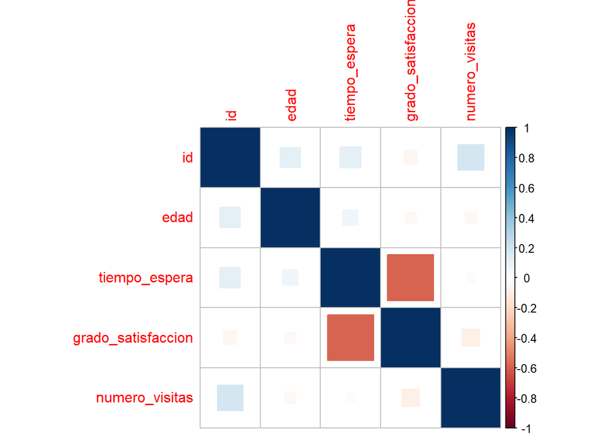

```r
datos |>
  select(where(is.numeric)) |>
  cor() |>
  corrplot::corrplot(method = "square")
```

#### 2.3.5 Ejercicio 5

📝 Investiga el paquete `{GGally}` y a función `ggpairs()` para visualizar las correlaciones de todas las variables (salvo `id`)

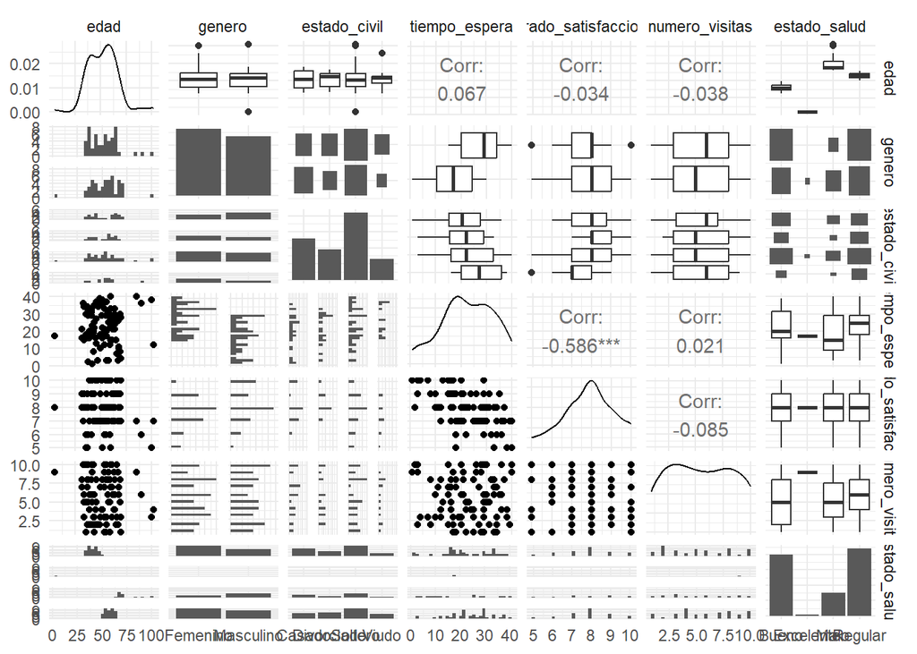

```r
library(GGally)
ggpairs(datos |> select(-id)) +
  theme_minimal()
```

```r
# cuali vs cuali: pictogramas (con rectángulos)
# cuanti vs cuanti: scatter plot
# cuanti vs cuali: boxplot desagregados
# variable vs sí misma: densidad
```

#### 2.3.6 Ejercicio 6

📝 ¿Cómo saber que la correlación observada entre `edad` y `grado_satisfaccion` ($-0.0339$) es suficientemente pequeña para considerarse incorreladas? ¿Cómo saber si la correlación entre `tiempo_espera` y `grado_satisfaccion` ($-0.586$) es suficientemente grande para considerar que es **significativa**?

```r
cor.test(datos$edad, datos$grado_satisfaccion)
```

```
    Pearson's product-moment correlation

data:  datos$edad and datos$grado_satisfaccion
t = -0.33562, df = 98, p-value = 0.7379
alternative hypothesis: true correlation is not equal to 0
95 percent confidence interval:
 -0.2287788  0.1636238
sample estimates:
        cor
-0.03388324
```

```r
cor.test(datos$tiempo_espera, datos$grado_satisfaccion)
```

```
    Pearson's product-moment correlation

data:  datos$tiempo_espera and datos$grado_satisfaccion
t = -7.1617, df = 98, p-value = 1.486e-10
alternative hypothesis: true correlation is not equal to 0
95 percent confidence interval:
 -0.7017625 -0.4404237
sample estimates:
       cor
-0.5861368
```

```r
# En uno el p-valor es bastante alto (**no rechazamos la hipótesis nula de incorrelación**) y en otro el p-valor es prácticamente 0 (rechazamos la hipótesis nula ->  **hay evidencias de correlación significativa**).

# Ninguna de las 3 es normal así que lo apropiado sería
# contrastar la correlación de rango
performance::check_normality(datos$edad)
performance::check_normality(datos$grado_satisfaccion)
performance::check_normality(datos$tiempo_espera)
```

[output not shown]

### 2.4 🐣 Caso práctico I: encuesta de satisfacción

Vamos a seguir poniendo en práctica lo aprendido el dataset `SatisfaccionPacientes.csv`

```r
library(readr)
datos <-
  read_csv(file = "./datos/SatisfaccionPacientes.csv") |>
  janitor::clean_names() |>
  mutate(estado_civil = factor(estado_civil),
         genero = factor(genero))
datos
```

```
# A tibble: 100 × 8
      id  edad genero    estado_civil tiempo_espera grado_satisfaccion
   <dbl> <dbl> <fct>     <fct>                <dbl>              <dbl>
 1     1    60 Masculino Casado                  28                  8
 2     2    44 Femenino  Soltero                 22                  8
 3     3    43 Masculino Soltero                  8                  9
 4     4    32 Masculino Soltero                 21                  8
 5     5    66 Masculino Divorciado               7                 10
 6     6    43 Masculino Divorciado              20                  8
 7     7    54 Masculino Casado                  18                  6
 8     8    55 Masculino Soltero                 29                  6
 9     9    56 Masculino Viudo                   17                  9
10    10    34 Femenino  Casado                  34                  8
# ℹ 90 more rows
# ℹ 2 more variables: numero_visitas <dbl>, estado_salud <chr>
```

#### 2.4.1 Pregunta 1

> Convierte de manera adecuada la variable `estado_salud` a cualitativa ORDINAL

```r
datos <-
  datos |>
  mutate(estado_salud =
           factor(estado_salud, levels = c("Malo", "Regular", "Bueno", "Excelente"),
                  ordered = TRUE))
```

#### 2.4.2 Pregunta 2

> Haz uso de `table()` para calcular la tabla de frecuencias de `genero` y `estado_civil`

```r
table(datos$genero)
table(datos$estado_civil)
```

[output not shown]

#### 2.4.3 Pregunta 3

> Calcula la tabla de frecuencias de las ORDINALES y piensa si ahora puedes añadir algo más a la tabla de frecuencias). Tras ello usa el código más sencillo para responder a: ¿cuántas personas tienen un estado de salud regular (o peor)?

```r
freq_estado_salud <-
  datos |>
  count(estado_salud) |>
  rename(frecuencia_abs = n) |>
  mutate(frecuencia_rel = frecuencia_abs/sum(frecuencia_abs),
         frecuencia_acum_abs = cumsum(frecuencia_abs),
         frecuencia_acum_rel = cumsum(frecuencia_rel))
# Se ve dentro de la tabla. Hay 44+15 = 59 personas con un estado de salud malo o regular.
# Con código
datos |>
  count(estado_salud <= "Regular")
```

[output not shown]

#### 2.4.4 Pregunta 4

> Si te fijas una de las modalidades es totalmente anecdótica (solo 1 Excelente). Sería conveniente recategorizar la categoría Excelente: siempre que detecte Excelente, lo debe recategorizar a Bueno (criterio general: las categorías deben contener al menos un 5% de los individuos de toda la muestra).

```r
datos <-
  datos |>
  mutate(estado_salud  = if_else(estado_salud  == "Excelente", "Bueno", estado_salud),
         # ojo: hay que redefinir los niveles de la cualitativa
         # ya que ha dejado de ser factor (veremos un día el paquete forcats para esto)
         estado_salud =
           factor(estado_salud, levels = c("Malo", "Regular", "Bueno"),
                  ordered = TRUE))
```

#### 2.4.5 Pregunta 5

> Calcula la media, mediana, rango intercuartílico y desviación típica de grado de satisfacción desagregado por sexo.

```r
resumen <-
  datos |>
  summarise(media_grado_satisfaccion = mean(grado_satisfaccion),
           sd_grado_satisfaccion = sd(grado_satisfaccion),
           mediana_grado_satisfaccion = median(grado_satisfaccion),
           IQR_grado_satisfaccion =
             quantile(grado_satisfaccion, probs = 0.75) -
             quantile(grado_satisfaccion, probs = 0.25),
           .by = genero)
```

#### 2.4.6 Pregunta 6

> Exporta los resultados anteriores (`resumen`) en un archivo `resumen.csv`. En lugar de un `read_csv()` vamos a usar `write_csv(tabla, file = "ruta")`

```r
# importado como csv
write_csv(resumen, file = "./resumen.csv")
```

#### 2.4.7 Pregunta 7

> Crear un diagrama de barras para la variable género. ¿Cómo podríamos decirle que cada barra (es decir, para cada modalidad de género) sea de un color (de relleno)?

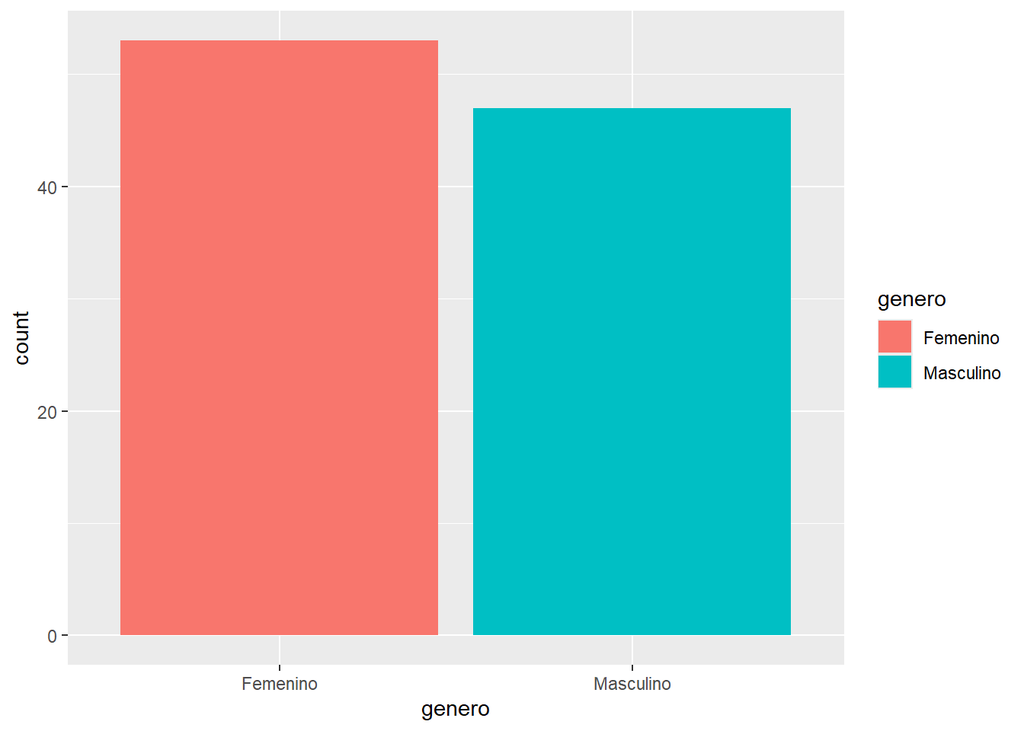

```r
ggplot(datos) +
  # dentro de aes() para que dependa de la tabla
  geom_bar(aes(x = genero, fill = genero))
```

#### 2.4.8 Pregunta 8

> Crear desde cero un diagrama de barras, con ajustes personalizados para la variable estado de salud

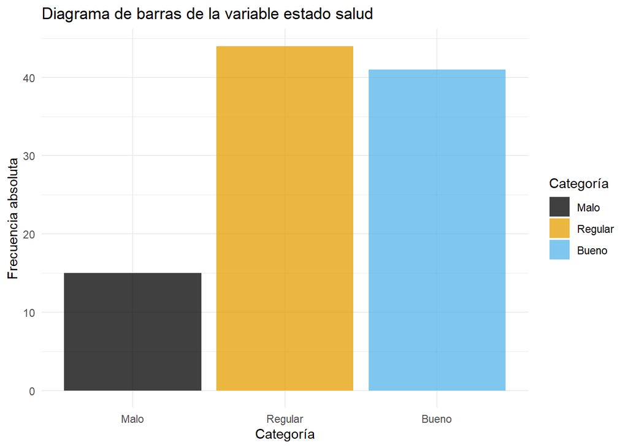

```r
# Estado de salud (ahora el orden importa)
ggplot(datos) +
  geom_bar(aes(x = estado_salud, fill = estado_salud), alpha = 0.75) +
  ggthemes::scale_fill_colorblind() +
  labs(title = "Diagrama de barras de la variable estado salud",
       x = "Categoría",  y = "Frecuencia absoluta",
       fill = "Categoría") +
  theme_minimal()
```

Fíjate que si **no tuviésemos la variable como cuali ordinal, las barras van por orden alfabético**, no por jerarquía real

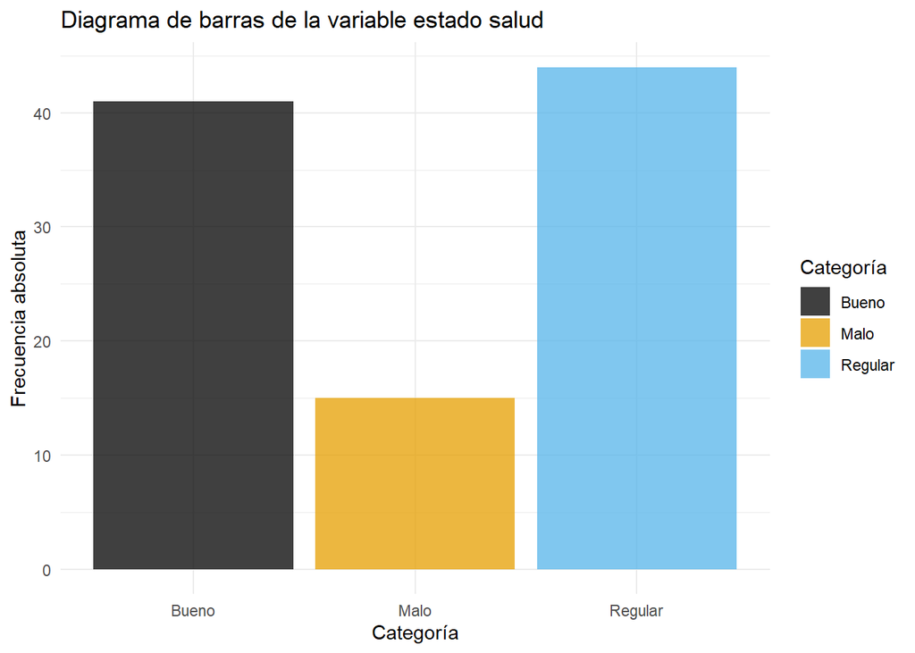

```r
ggplot(datos) +
  geom_bar(aes(x = as.character(estado_salud), fill = as.character(estado_salud)),
           alpha = 0.75) +
  ggthemes::scale_fill_colorblind() +
  labs(title = "Diagrama de barras de la variable estado salud",
       x = "Categoría",  y = "Frecuencia absoluta",
       fill = "Categoría") +
  theme_minimal()
```

#### 2.4.9 Pregunta 9

> Crea el histograma inferior para las variable edad y tiempo de espera.

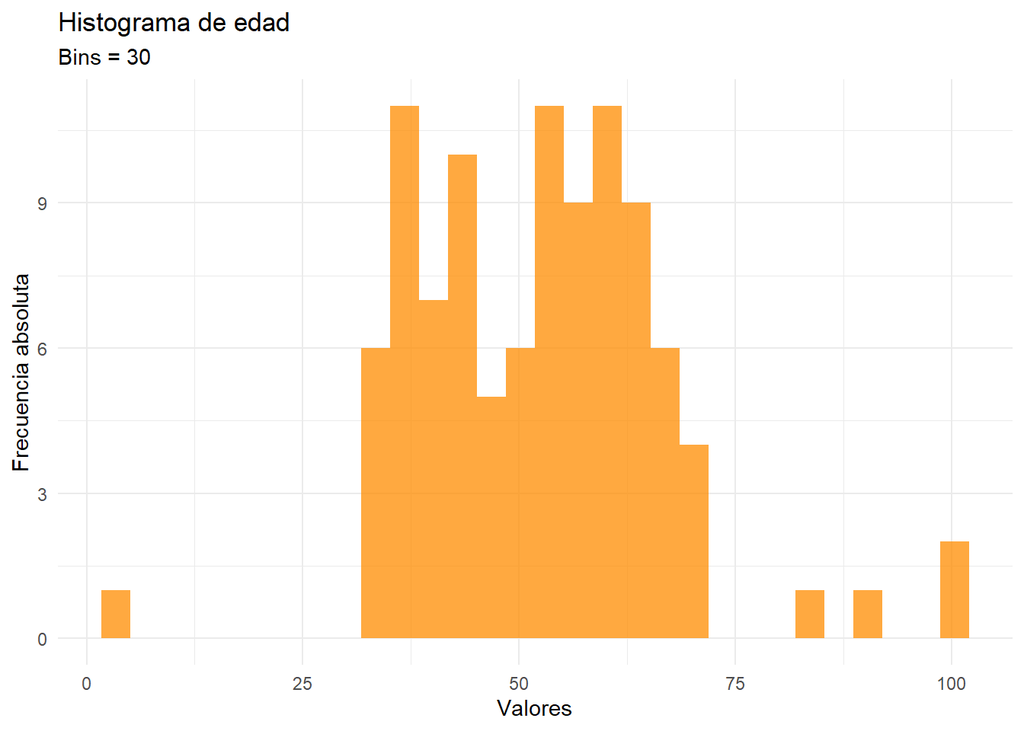

```r
ggplot(datos) +
  geom_histogram(aes(x = edad), bins = 30, fill = "darkorange", alpha = 0.75) +
  labs(title = "Histograma de edad", subtitle = "Bins = 30",
       x = "Valores", y = "Frecuencia absoluta") +
  theme_minimal()
```

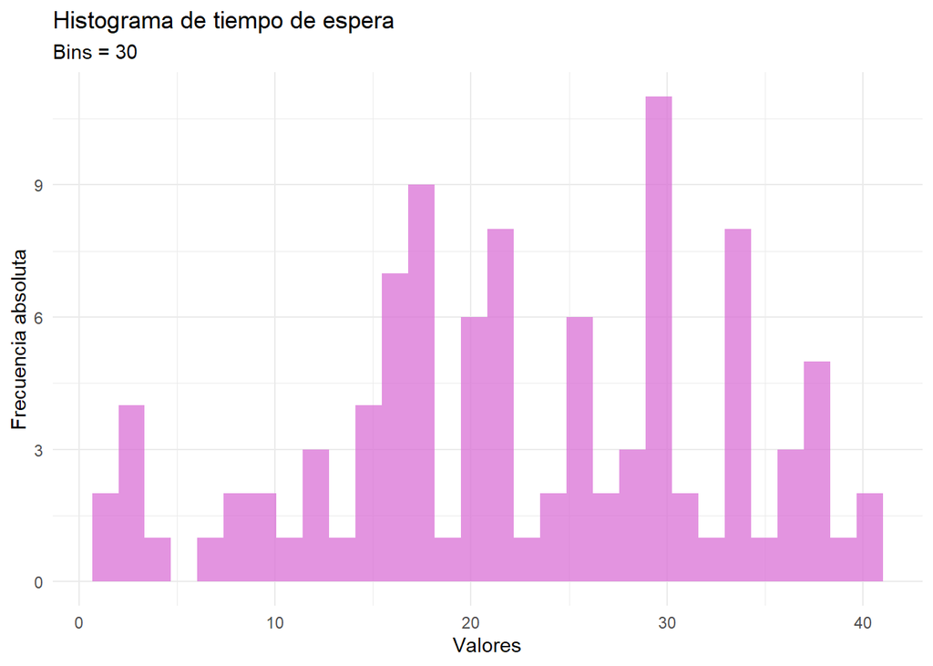

```r
ggplot(datos) +
  # Define el ancho de las barras y colores
  geom_histogram(aes(x = tiempo_espera), bins = 30, fill = "orchid", alpha = 0.75) +
  labs(title = "Histograma de tiempo de espera", subtitle = "Bins = 30",
       x = "Valores", y = "Frecuencia absoluta") +
  theme_minimal()
```

#### 2.4.10 Pregunta 10

> Crea el gráfico de densidad inferior para las variable edad y tiempo de espera.

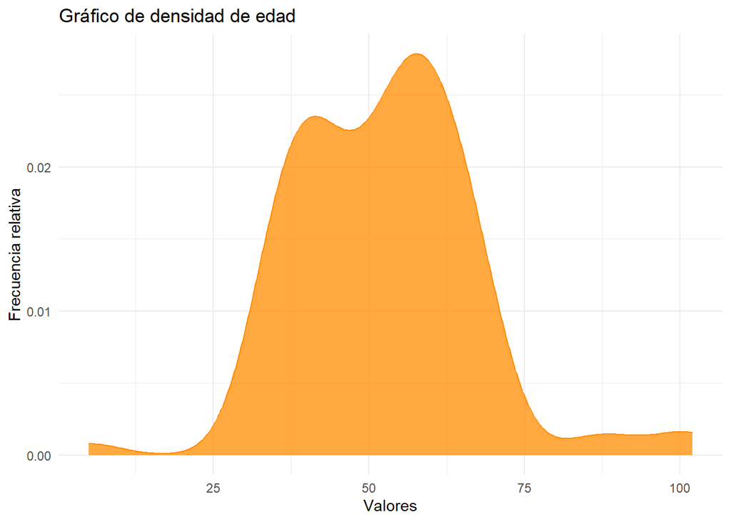

```r
ggplot(datos) +
  geom_density(aes(x = edad), color = "darkorange",
               fill = "darkorange", alpha = 0.75) +
  labs(title = "Gráfico de densidad de edad",
       x = "Valores", y = "Frecuencia relativa") +
  theme_minimal()
```

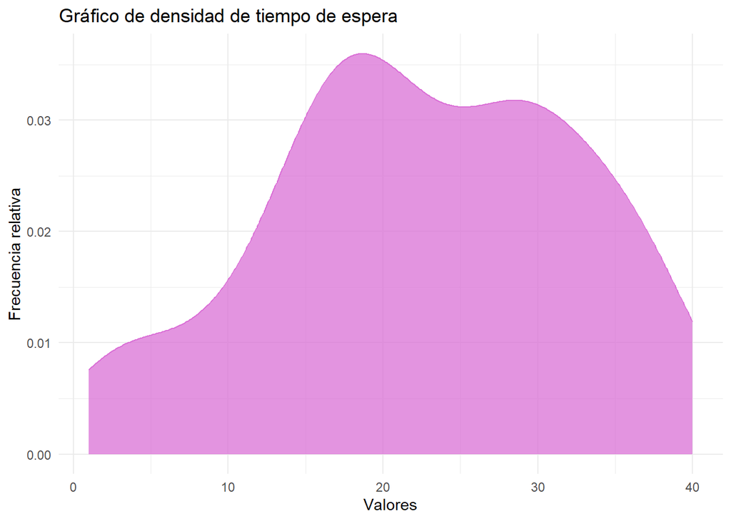

```r
ggplot(datos) +
  geom_density(aes(x = tiempo_espera), color = "orchid",
               fill = "orchid", alpha = 0.75) +
  labs(title = "Gráfico de densidad de tiempo de espera",
       x = "Valores", y = "Frecuencia relativa") +
  theme_minimal()
```

#### 2.4.11 Pregunta 11

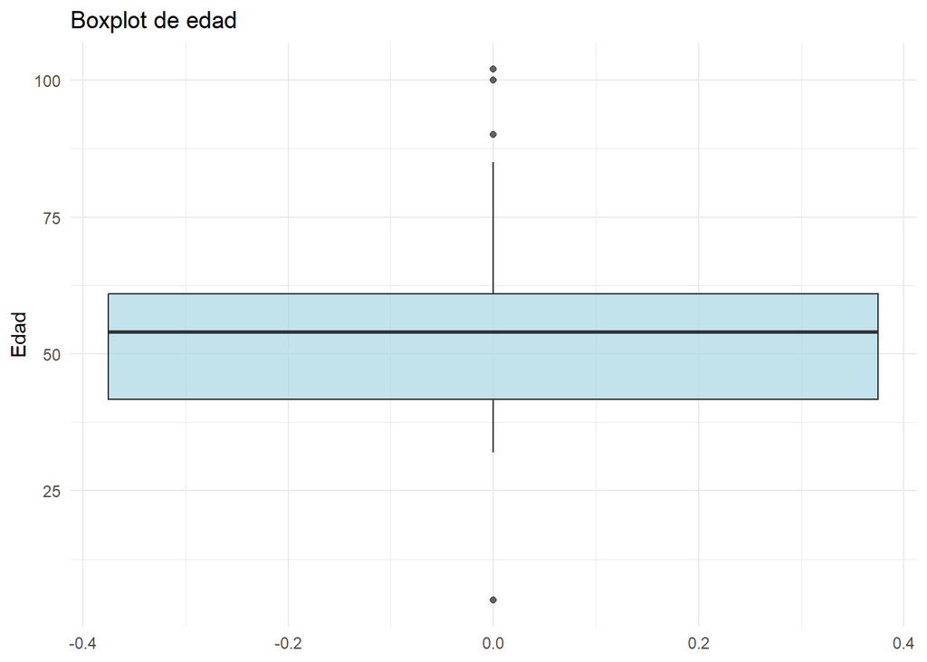

```r
ggplot(datos) +
  geom_boxplot(aes(y = edad), fill = "lightblue", alpha = 0.75) +
  labs(title = "Boxplot de edad",  y = "Edad") +
  theme_minimal()
```

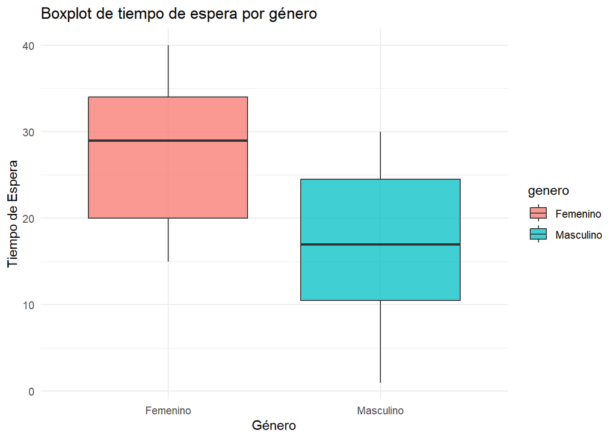

```r
ggplot(datos) +
  geom_boxplot(aes(x = genero, y = tiempo_espera, fill = genero),
               alpha = 0.75) +
  labs(title = "Boxplot de tiempo de espera por género",
       x = "Género", y = "Tiempo de Espera") +
  theme_minimal()
```

> Haciendo uso del gráfico anterior:
1. ¿La variable edad tiene outliers? ¿Qué edad tienen esos pacientes?
2. ¿Quién ha esperado más los hombres o las mujeres?